# prob4-cp1

## Conhecendo os Dados

Os dados são referentes a avaliações de filmes, feitas por usuários, coletadas aleatóriamente pelo [Movielens](https://movielens.org/) disponibilizados no [site](http://grouplens.org/datasets/movielens/latest/). O conjunto de dados escolhido é o de menor volume, cerca de 10.000 filmes com 100.000 avaliações. Os dados são de 668 usuários entre abril 1996 ate janeiro de 2016.

```r
movies = read.csv("dados/ml-latest-small/movies.csv", stringsAsFactors = F)
rating = read.csv("dados/ml-latest-small/ratings.csv", stringsAsFactors = F)
tags = read.csv("dados/ml-latest-small/tags.csv", stringsAsFactors = F)
links = read.csv("dados/ml-latest-small/links.csv", stringsAsFactors = F)
movie.genre = read.csv("dados/movie-genre.csv", stringsAsFactors = F)

head(movies)
```

```
##   movieId                              title
## 1       1                   Toy Story (1995)
## 2       2                     Jumanji (1995)
## 3       3            Grumpier Old Men (1995)
## 4       4           Waiting to Exhale (1995)
## 5       5 Father of the Bride Part II (1995)
## 6       6                        Heat (1995)
##                                        genres
## 1 Adventure|Animation|Children|Comedy|Fantasy
## 2                  Adventure|Children|Fantasy
## 3                              Comedy|Romance
## 4                        Comedy|Drama|Romance
## 5                                      Comedy
## 6                       Action|Crime|Thriller
```

```r
summary(rating$rating)
```

```
##    Min. 1st Qu.  Median    Mean 3rd Qu.    Max.
##   0.500   3.000   3.500   3.517   4.000   5.000
```

```r
#merge dos dataframes movies e rating
data.movies <- merge(movies, rating, by = "movieId")
```

## Parte 1

Escolha uma trilogia (ou uma n-logia com n > 3) e avalie para qual dos episódios da trilogia há melhor avaliação e para qual há mais variação nas notas atribuídas ao filme. (Exemplos: Poderoso Chefão, Star Wars, Matrix, etc.)

A trilogia escolhida foi a do filme Matrix. Vejamos quantas avaliações tem cada filme.

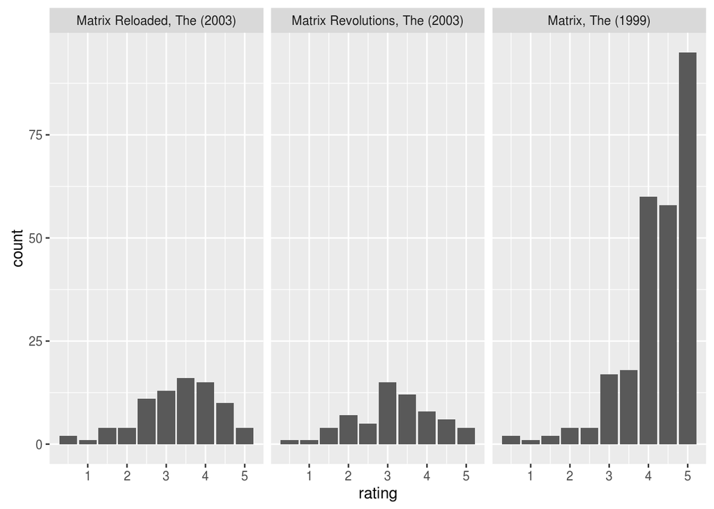

```r
#vetor com os ids dos filmes matrix
movies.matrix.ids = c(2571, 6365, 6934)

#dataset com todos os filmes de matrix
matrix.movies <- data.movies %>%
  filter(movieId %in% movies.matrix.ids )

#datasets separados por filmes
matrix1 <- data.movies %>% filter(movieId == 2571)
matrix2 <- data.movies %>% filter(movieId == 6365)
matrix3 <- data.movies %>% filter(movieId == 6934)


p <- ggplot(matrix.movies, aes(rating)) + geom_bar()
p + facet_grid(. ~ title, scales = c("free_y"))
```

Devido aos valores das avaliações possuirem extremos, optamos por utilizar o intervalo de confiança feito com a mediana dos valores.

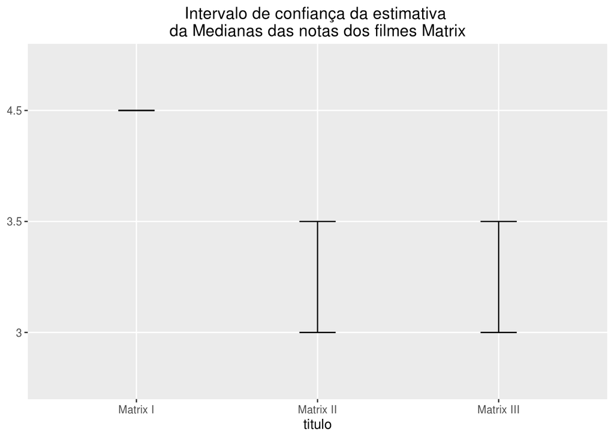

```r
# install.packages("resample")
library(resample)
# concorrente: boot

bootstrap.mediana.matrix1 = bootstrap(matrix1$rating, median, R = 1000)
mediana.matrix1 = CI.percentile(bootstrap.mediana.matrix1, probs = c(.025, .975))

bootstrap.mediana.matrix2 = bootstrap(matrix2$rating, median, R = 1000)
mediana.matrix2 = CI.percentile(bootstrap.mediana.matrix2, probs = c(.025, .975))

bootstrap.mediana.matrix3 = bootstrap(matrix3$rating, median, R = 1000)
mediana.matrix3 = CI.percentile(bootstrap.mediana.matrix3, probs = c(.025, .975))


medianas.matrix <- data.frame(
  rbind(
    c("Matrix I", mediana.matrix1),
    c("Matrix II", mediana.matrix2),
    c("Matrix III", mediana.matrix3)
  )
)

names(medianas.matrix) = c("titulo", "limite.inferior", "limite.superior")

ggplot(medianas.matrix, aes(x = titulo, ymin = limite.inferior, ymax = limite.superior)) +
  geom_errorbar(width = .2) +
  ggtitle("Intervalo de confiança da estimativa \nda Medianas das notas dos filmes Matrix")
```

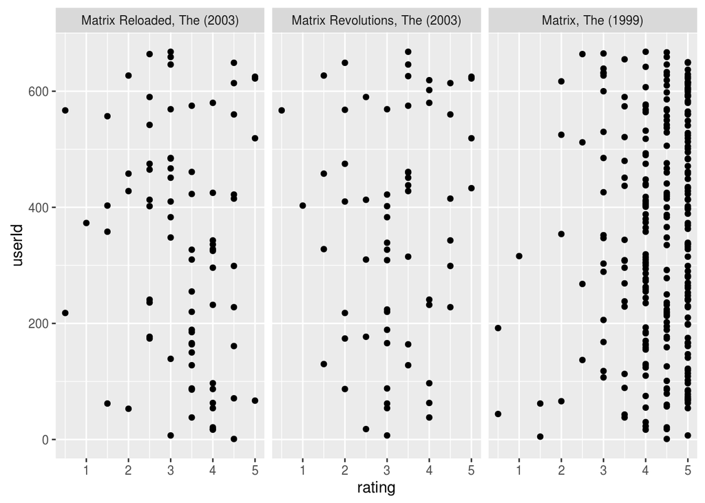

```r
g <- ggplot(matrix.movies, aes(x=rating, y=userId)) + geom_point()
g + facet_grid(. ~ title, scales = c("free_y"))
```

Analisando as notas atribuidas pelos usuários, podemos concluir que as observações feitas antes, condizem com a realidade. O primeiro filme é bem considerado como o melhor e os outros dois tem as avaliações bem parecidas.

## Parte 2

Na segunda parte da nossa análise, vamos observar o relacionamento existente entre a quantidade de gêneros que cada filme possui. Temos o objetivos de verificar se existe realmente uma correlação com a quantidade de gêneros que os filmes tem e as avaliações que eles recebem. Vamos dar uma olhada nos dados.

```r
head(movies)
```

```
##   movieId                              title
## 1       1                   Toy Story (1995)
## 2       2                     Jumanji (1995)
## 3       3            Grumpier Old Men (1995)
## 4       4           Waiting to Exhale (1995)
## 5       5 Father of the Bride Part II (1995)
## 6       6                        Heat (1995)
##                                        genres
## 1 Adventure|Animation|Children|Comedy|Fantasy
## 2                  Adventure|Children|Fantasy
## 3                              Comedy|Romance
## 4                        Comedy|Drama|Romance
## 5                                      Comedy
## 6                       Action|Crime|Thriller
```

Para facilitar nossa análise, obtivemos os dados anteriores em um formato diferente. Os filmes foram separados por um único gênero.

```r
head(movie.genre)
```

```
##   movieId            title     genre
## 1       1 Toy Story (1995) Adventure
## 2       1 Toy Story (1995) Animation
## 3       1 Toy Story (1995)  Children
## 4       1 Toy Story (1995)    Comedy
## 5       1 Toy Story (1995)   Fantasy
## 6       2   Jumanji (1995) Adventure
```

Iniciando nossa análise, tivemos que organizar os dados e retirar algumas não conformidades, como os filmes que não possuiam gênero.

```r
genre.median <- data.frame(movieId=numeric(0), n=numeric(0), mediana=numeric(0))


for(id in 1:149532){
  #se existir filme com id n
  if(nrow( subset(movie.genre, movieId == id) ) > 0){

    id <- as.numeric(id)
    avaliacoes1 <- subset(rating, movieId == id)
    #se esse filme possui avaliacoes
    if(nrow(avaliacoes1) > 0){

      # se filme possui um gênero e é no genre
      if(length(movie.genre$genre[movie.genre$movieId==id]) == 1 & movie.genre$genre[movie.genre$movieId==id]  == "(no genres listed)"){
        v.n <- 0
      }
      else{
          # n é quantidade de gêneros
          v.n <- as.numeric(sum(movie.genre$movieId == id))
      }
      # calcula mediana de avaliaçÕes do filme
      v.mediana <- median(avaliacoes1$rating)
      # adiciona na tabela
      genre.median <- rbind(genre.median, data.frame(movieId = id, n = v.n, mediana = v.mediana))
    }
  }
}

str(genre.median)
```

```
## 'data.frame':    10325 obs. of  3 variables:
##  $ movieId: num  1 2 3 4 5 6 7 8 9 10 ...
##  $ n      : num  5 3 2 3 1 3 2 2 1 3 ...
##  $ mediana: num  4 3 3 3 3 4 3 4 3 3.5 ...
```

Iremos novamente aplicar bootstrap nessa amostra de dados. Para melhorar a nossa observação, foram descartados os filmes que possuem mais de seis gêneros. O resultado é um gráfico como o anterior, mas agora representando os intervalos com valores que as medianas podem assumir em cada grupo.

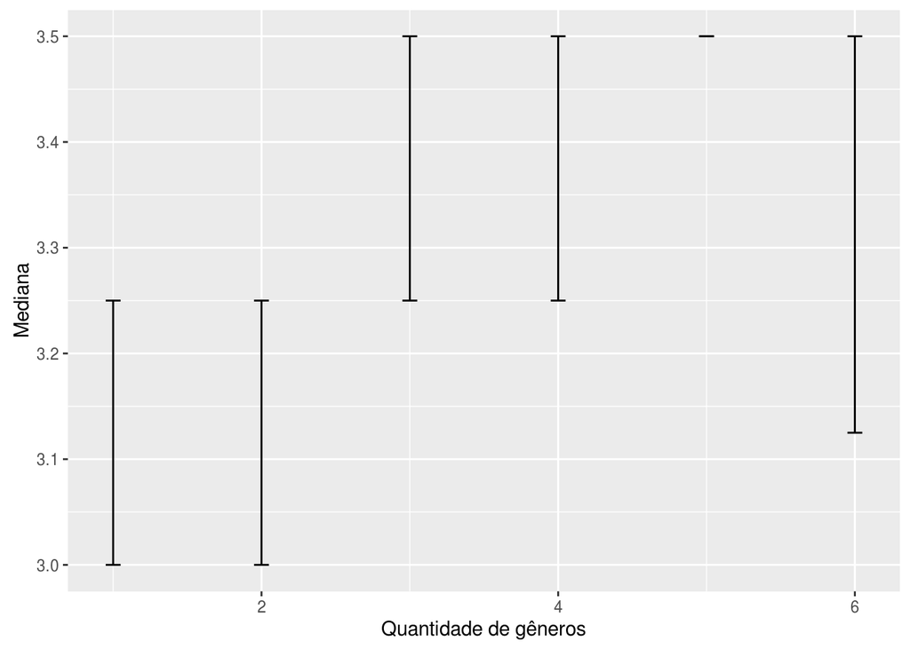

```r
df <- data.frame()

for(i in 1:6){
  b = bootstrap(subset(genre.median, n==i) , median(mediana))
  median.mv = CI.percentile(b, probs = c(.025, .975))
  df <- data.frame(rbind(df, data.frame(median.mv)))
}

df$Generos = c(1,2,3,4,5,6)

df %>%
  ggplot(aes(x = Generos, ymin = X2.5., ymax = X97.5.)) +
  geom_errorbar(width = .1) + labs(x="Quantidade de gêneros", y="Mediana")
```

Observando os resultados obtidos, conseguimos notar que existem grupos que possuem o mesmo comportamento, por exemplo o grupo 1 e 2, 3 e 4. Vemos que os quatro últimos grupos possuem o valor máximo da mediana é 3.5, mas só o grupo de filmes com 5 gêneros possui um intervalo sem variação. Concluímos que os filmes classificados com 5 gêneros em geral são melhores avaliados.

```r
b.diff.means = bootstrap2(data = subset(genre.median, mediana == 5)$mediana,
                          data2 = subset(genre.median, mediana == 1)$mediana,
                          median)

means.diff = CI.percentile(b.diff.means, probs = c(.025, .975))
means.diff
```

```
##                    2.5% 97.5%
## median: data-data2    4     4
```

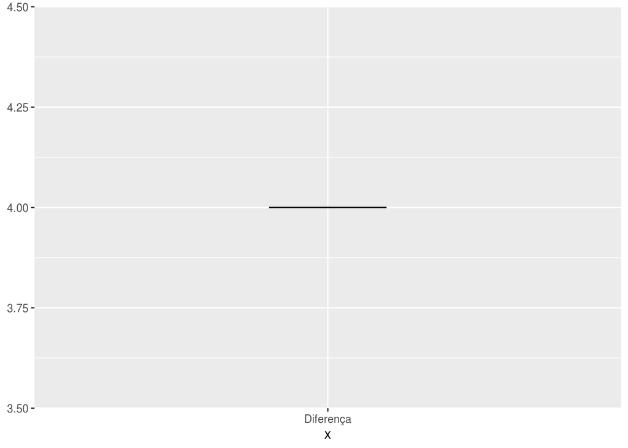

```r
data.frame(means.diff) %>%
  ggplot(aes(x = "Diferença", ymin = X2.5., ymax = X97.5.)) +
  geom_errorbar(width = .2)
```